# 회귀분석

## 다중회귀분석

```r
library(MVN)
library(car)
library(forecast)
library(lsr)
library(MASS)

#원본데이터
real<-read.csv('/Users/SELEN/Downloads/WorldHappiness_Corruption_2015_2020.csv')

#파이썬에서 결측값 전처리한 데이터
df=read.csv('/Users/SELEN/Downloads/happiness.csv')
head(df)
```

```
##       Country happiness_score gdp_per_capita   family    health   freedom
## 1      Norway           7.537       1.616463 1.533524 0.7966665 0.6354226
## 2     Denmark           7.522       1.482383 1.551122 0.7925655 0.6260067
## 3     Iceland           7.504       1.480633 1.610574 0.8335521 0.6271626
## 4 Switzerland           7.494       1.564980 1.516912 0.8581313 0.6200706
## 5     Finland           7.469       1.443572 1.540247 0.8091577 0.6179509
## 6 Netherlands           7.377       1.503945 1.428939 0.8106961 0.5853845
##   generosity government_trust dystopia_residual continent Year social_support
## 1  0.3620122        0.3159638          2.277027    Europe 2015       1.553057
## 2  0.3552805        0.4007701          2.313707    Europe 2015       1.555483
## 3  0.4755402        0.1535266          2.322715    Europe 2015       1.605189
## 4  0.2905493        0.3670073          2.276716    Europe 2015       1.515801
## 5  0.2454828        0.3826115          2.430182    Europe 2015       1.559509
## 6  0.4704898        0.2826618          2.294804    Europe 2015       1.491215
##   cpi_score
## 1        88
## 2        91
## 3        79
## 4        86
## 5        90
## 6        84
```

```r
summary(df)
```

```
##    Country          happiness_score gdp_per_capita       family
##  Length:792         Min.   :2.567   Min.   :0.0153   Min.   :0.1042
##  Class :character   1st Qu.:4.591   1st Qu.:0.6442   1st Qu.:0.8440
##  Mode  :character   Median :5.486   Median :0.9945   Median :1.0517
##                     Mean   :5.473   Mean   :0.9293   Mean   :1.0107
##                     3rd Qu.:6.301   3rd Qu.:1.2287   3rd Qu.:1.2401
##                     Max.   :7.809   Max.   :2.0960   Max.   :1.6106
##      health            freedom         generosity      government_trust
##  Min.   :0.005565   Min.   :0.0250   Min.   :0.00199   Min.   :0.0008296
##  1st Qu.:0.510070   1st Qu.:0.3254   1st Qu.:0.12798   1st Qu.:0.0528625
##  Median :0.685397   Median :0.4396   Median :0.19932   Median :0.0890000
##  Mean   :0.649261   Mean   :0.4277   Mean   :0.21406   Mean   :0.1258049
##  3rd Qu.:0.815641   3rd Qu.:0.5463   3rd Qu.:0.27325   3rd Qu.:0.1542500
##  Max.   :1.141000   Max.   :0.7240   Max.   :0.83808   Max.   :0.5519100
##  dystopia_residual  continent              Year      social_support
##  Min.   :0.2572    Length:792         Min.   :2015   Min.   :0.3524
##  1st Qu.:1.7533    Class :character   1st Qu.:2016   1st Qu.:1.0712
##  Median :2.0734    Mode  :character   Median :2018   Median :1.2765
##  Mean   :2.0689                       Mean   :2018   Mean   :1.2186
##  3rd Qu.:2.3945                       3rd Qu.:2019   3rd Qu.:1.4445
##  Max.   :3.6021                       Max.   :2020   Max.   :1.6440
##    cpi_score
##  Min.   :11.00
##  1st Qu.:30.00
##  Median :38.00
##  Mean   :44.33
##  3rd Qu.:57.00
##  Max.   :91.00
```

# 회귀분석

```r
lm_df_f<-lm(data=df, happiness_score~gdp_per_capita+family+health+freedom+generosity+government_trust+dystopia_residual+Year+social_support+cpi_score)
summary(lm_df_f)
```

```
##
## Call:
## lm(formula = happiness_score ~ gdp_per_capita + family + health +
##     freedom + generosity + government_trust + dystopia_residual +
##     Year + social_support + cpi_score, data = df)
##
## Residuals:
##      Min       1Q   Median       3Q      Max
## -0.98139 -0.05983 -0.00365  0.04580  0.89139
##
## Coefficients:
##                     Estimate Std. Error t value Pr(>|t|)
## (Intercept)       -4.673e+01  8.020e+00  -5.827 8.26e-09 ***
## gdp_per_capita     9.428e-01  3.049e-02  30.923  < 2e-16 ***
## family             9.742e-01  4.545e-02  21.432  < 2e-16 ***
## health             1.028e+00  4.389e-02  23.418  < 2e-16 ***
## freedom            1.125e+00  5.202e-02  21.628  < 2e-16 ***
## generosity         8.765e-01  5.345e-02  16.400  < 2e-16 ***
## government_trust   7.927e-01  7.371e-02  10.753  < 2e-16 ***
## dystopia_residual  9.690e-01  1.160e-02  83.557  < 2e-16 ***
## Year               2.319e-02  3.976e-03   5.832 8.03e-09 ***
## social_support     4.761e-02  5.195e-02   0.917  0.35967
## cpi_score          1.477e-03  5.331e-04   2.770  0.00573 **
## ---
## Signif. codes:  0 '***' 0.001 '**' 0.01 '*' 0.05 '.' 0.1 ' ' 1
##
## Residual standard error: 0.1649 on 781 degrees of freedom
## Multiple R-squared:  0.9788, Adjusted R-squared:  0.9785
## F-statistic:  3601 on 10 and 781 DF,  p-value: < 2.2e-16
```

social_support 변수의 p값이 0.35967>0.05 이므로 유의하지 않은 변수이다.

### 단계적 선택법

```r
null_reg<-lm(happiness_score~1, data=df) #영모형
reg<-step(null_reg, direction = "both", scope = list(lower=null_reg,upper=lm_df_f))
```

```
## Start:  AIC=187.18
## happiness_score ~ 1
##
##                     Df Sum of Sq     RSS     AIC
## + gdp_per_capita     1    629.77  370.85 -596.94
## + social_support     1    584.91  415.71 -506.50
## + health             1    572.14  428.48 -482.54
## + cpi_score          1    480.55  520.07 -329.11
## + family             1    455.71  544.92 -292.15
## + freedom            1    294.62  706.00  -87.04
## + dystopia_residual  1    271.93  728.69  -61.98
## + government_trust   1    207.91  792.72    4.72
## + generosity         1     23.77  976.85  170.14
## <none>                           1000.62  187.18
## + Year               1      0.55 1000.07  188.74
##
## Step:  AIC=-596.94
## happiness_score ~ gdp_per_capita
##
##                     Df Sum of Sq     RSS      AIC
## + dystopia_residual  1    199.67  171.18 -1207.24
## + freedom            1     84.15  286.69  -798.79
## + social_support     1     71.20  299.65  -763.78
## + health             1     49.73  321.12  -708.98
## + family             1     48.29  322.56  -705.44
## + cpi_score          1     35.71  335.14  -675.12
## + government_trust   1     33.47  337.38  -669.85
## + generosity         1     26.13  344.72  -652.82
## + Year               1      2.67  368.17  -600.68
## <none>                            370.85  -596.94
## - gdp_per_capita     1    629.77 1000.62   187.18
##
## Step:  AIC=-1207.24
## happiness_score ~ gdp_per_capita + dystopia_residual
##
##                     Df Sum of Sq    RSS      AIC
## + freedom            1     84.72  86.46 -1746.21
## + family             1     65.78 105.39 -1589.36
## + social_support     1     49.63 121.55 -1476.42
## + health             1     37.31 133.86 -1399.97
```

[output cut: 111 more lines]

```
##     family + health + generosity + government_trust + Year +
##     cpi_score
##
##                     Df Sum of Sq     RSS      AIC
## <none>                            21.263 -2845.13
## + social_support     1     0.023  21.240 -2843.98
## - cpi_score          1     0.197  21.460 -2839.81
## - Year               1     1.120  22.383 -2806.48
## - government_trust   1     3.122  24.385 -2738.63
## - generosity         1     7.514  28.777 -2607.47
## - freedom            1    12.715  33.979 -2475.87
## - health             1    16.002  37.265 -2402.76
## - gdp_per_capita     1    28.788  50.051 -2169.12
## - family             1    31.137  52.401 -2132.79
## - dystopia_residual  1   200.177 221.440  -991.33
```

AIC를 평가 기준으로 하여 단계적 선택법을 적용한 결과 social support를 제외했을 때가 AIC가 제일 낮으므로 최적의 모델이다.

- AIC = -2*loglikelihood+2*q 로 모형의 적합도와 복잡도를 반영한 값이다.

```r
summary(reg)
```

```
##
## Call:
## lm(formula = happiness_score ~ gdp_per_capita + dystopia_residual +
##     freedom + family + health + generosity + government_trust +
##     Year + cpi_score, data = df)
##
## Residuals:
##      Min       1Q   Median       3Q      Max
## -0.98158 -0.05691 -0.00475  0.04524  0.88300
##
## Coefficients:
##                     Estimate Std. Error t value Pr(>|t|)
## (Intercept)       -4.896e+01  7.640e+00  -6.408 2.54e-10 ***
## gdp_per_capita     9.507e-01  2.922e-02  32.538  < 2e-16 ***
## dystopia_residual  9.713e-01  1.132e-02  85.802  < 2e-16 ***
## freedom            1.125e+00  5.201e-02  21.625  < 2e-16 ***
## family             1.006e+00  2.972e-02  33.840  < 2e-16 ***
## health             1.037e+00  4.274e-02  24.259  < 2e-16 ***
## generosity         8.822e-01  5.307e-02  16.623  < 2e-16 ***
## government_trust   7.868e-01  7.343e-02  10.715  < 2e-16 ***
## Year               2.430e-02  3.786e-03   6.418 2.40e-10 ***
## cpi_score          1.429e-03  5.304e-04   2.693  0.00722 **
## ---
## Signif. codes:  0 '***' 0.001 '**' 0.01 '*' 0.05 '.' 0.1 ' ' 1
##
## Residual standard error: 0.1649 on 782 degrees of freedom
## Multiple R-squared:  0.9788, Adjusted R-squared:  0.9785
## F-statistic:  4002 on 9 and 782 DF,  p-value: < 2.2e-16
```

social support 제거된 모델인 reg의 정보를 확인해 보면 모든 변수가 유의하다. Adjusted R-squared은 0.9785로 높은 설명력을 가진다.

```r
anova(reg)
```

```
## Analysis of Variance Table
##
## Response: happiness_score
##                    Df Sum Sq Mean Sq    F value    Pr(>F)
## gdp_per_capita      1 629.77  629.77 23161.2894 < 2.2e-16 ***
## dystopia_residual   1 199.67  199.67  7343.3623 < 2.2e-16 ***
## freedom             1  84.72   84.72  3115.7412 < 2.2e-16 ***
## family              1  31.45   31.45  1156.6875 < 2.2e-16 ***
## health              1  17.20   17.20   632.5570 < 2.2e-16 ***
## generosity          1  10.30   10.30   378.6465 < 2.2e-16 ***
## government_trust    1   4.95    4.95   181.8959 < 2.2e-16 ***
## Year                1   1.10    1.10    40.5927 3.199e-10 ***
## cpi_score           1   0.20    0.20     7.2546  0.007224 **
## Residuals         782  21.26    0.03
## ---
## Signif. codes:  0 '***' 0.001 '**' 0.01 '*' 0.05 '.' 0.1 ' ' 1
```

회귀모형의 순차분산분석을 실시하여 추가적으로 설명하는 SSR을 알 수 있다.

# 모형진단

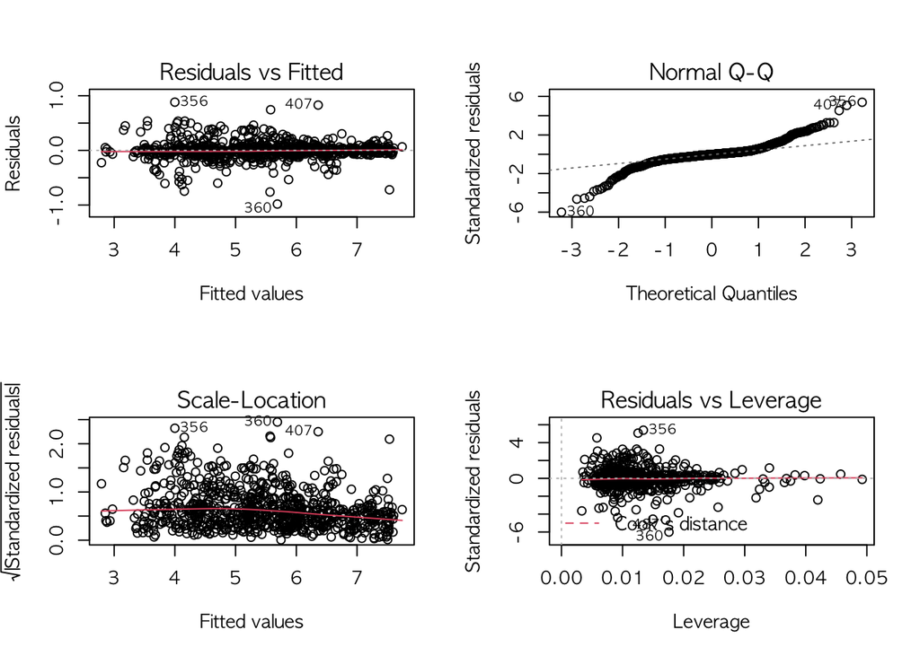

```r
par(mfrow = c(2, 2))
plot(reg)
```

회귀 모형은 오차의 등분산성, 정규성, 독립성을, 회귀모형의 선형성을 만족해야한다.

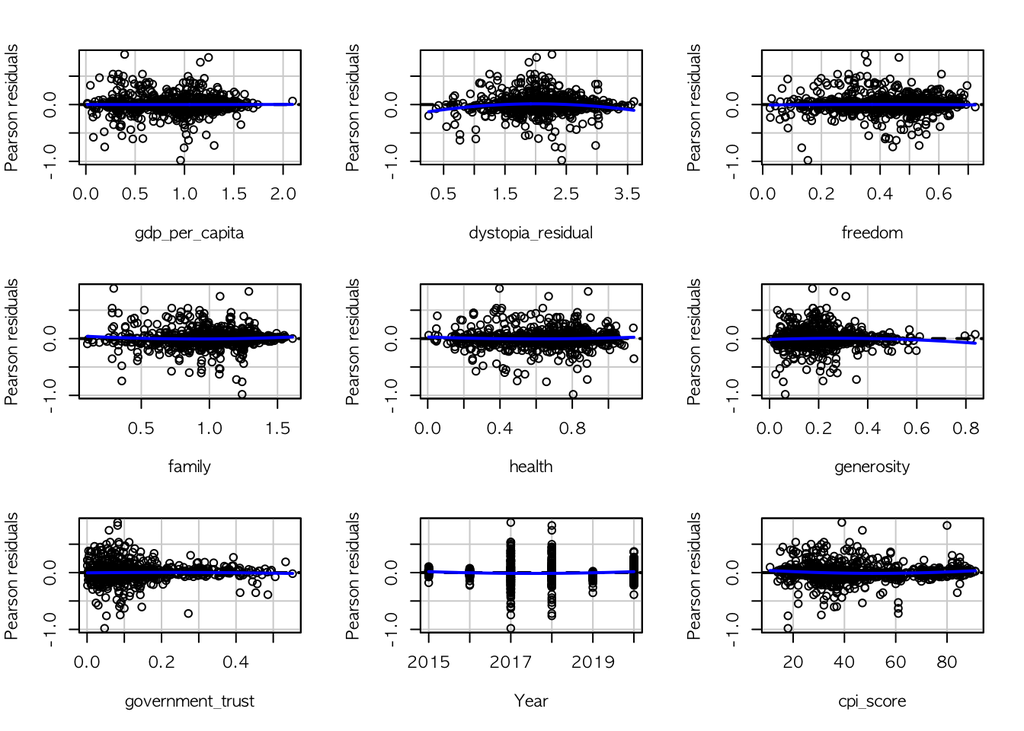

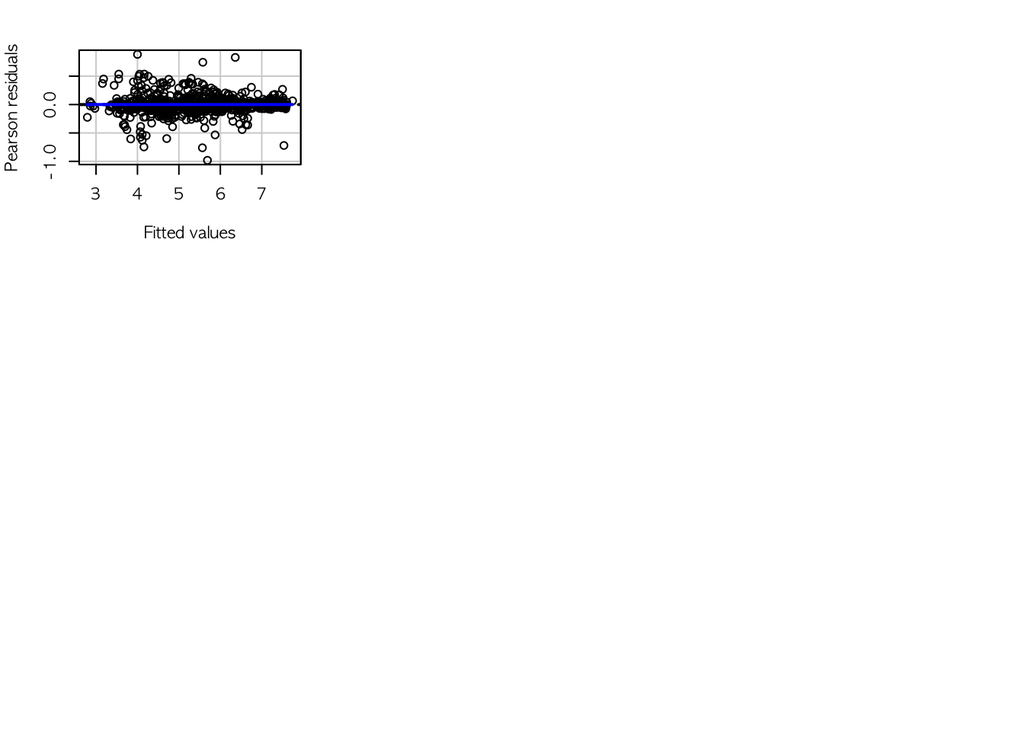

```
##                   Test stat Pr(>|Test stat|)
## gdp_per_capita       0.0586         0.953267
## dystopia_residual   -3.4314         0.000632 ***
## freedom             -0.2700         0.787218
## family               1.3813         0.167586
## health               1.1333         0.257442
## generosity          -1.2402         0.215283
## government_trust    -0.4008         0.688709
## Year                 2.2322         0.025881 *
## cpi_score            2.3926         0.016966 *
## Tukey test           0.0379         0.969729
## ---
## Signif. codes:  0 '***' 0.001 '**' 0.01 '*' 0.05 '.' 0.1 ' ' 1
```

```r
#잔차 plot
residualPlots(reg)
```

각 변수에 대해 잔차 설명변수 산점도를 그려 등분산성과 선형성을 알 수 있다.

### 1. 정규성

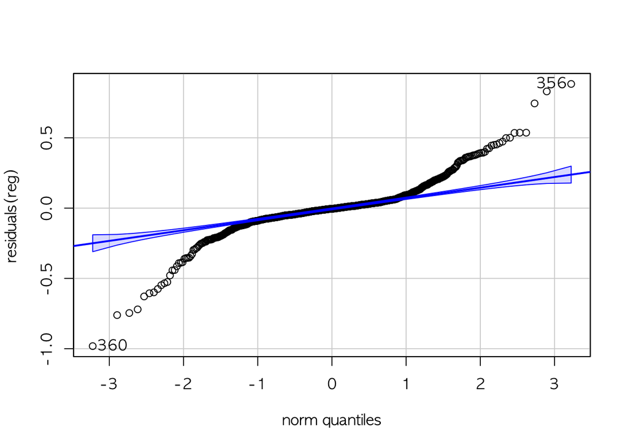

```
## [1] 360 356
```

```r
qqPlot(residuals(reg))
```

qqplot을 그려보면 정규성에서 벗어나는 것을 볼 수 있다. *파란 선에 가까울 수록 정규성을 만족한다.

```r
shapiro.test(residuals(reg))
```

```
##
##  Shapiro-Wilk normality test
##
## data:  residuals(reg)
## W = 0.86124, p-value < 2.2e-16
```

shapiro-wilk 검정을 이용하면 p 값이 <.001이므로 오차가 정규분포를 따른다는 귀무가설을 기각한다. 즉, 오차의 정규성을 가정할 수 없다.

### 2. 선형성

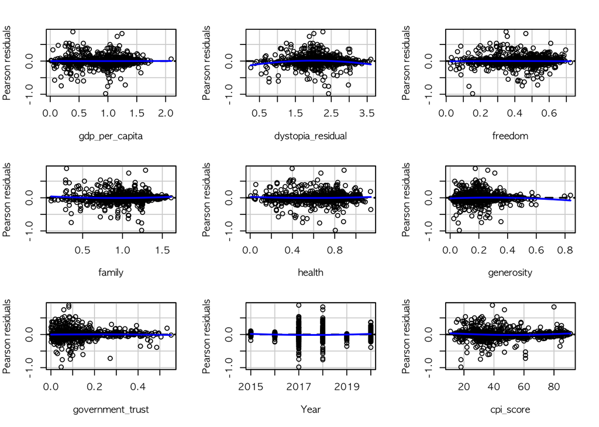

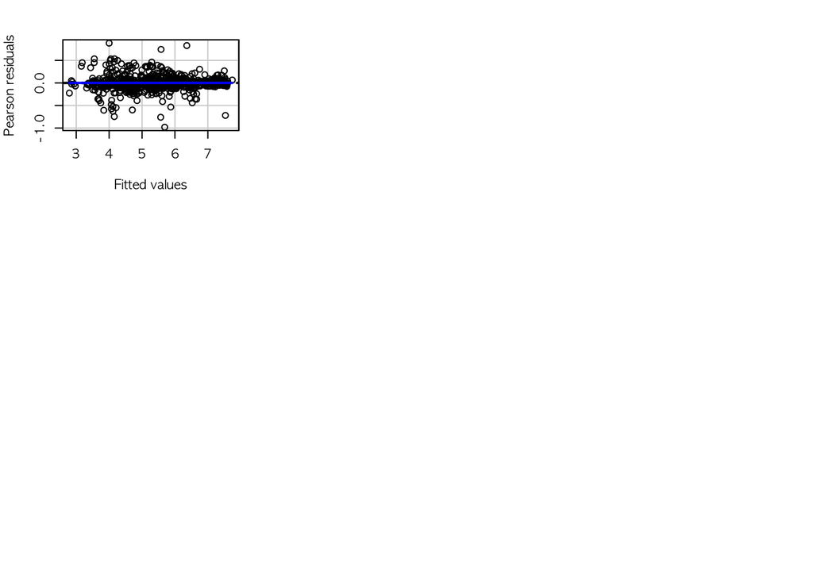

```
##                   Test stat Pr(>|Test stat|)
## gdp_per_capita       0.0586         0.953267
## dystopia_residual   -3.4314         0.000632 ***
## freedom             -0.2700         0.787218
## family               1.3813         0.167586
## health               1.1333         0.257442
## generosity          -1.2402         0.215283
## government_trust    -0.4008         0.688709
## Year                 2.2322         0.025881 *
## cpi_score            2.3926         0.016966 *
## Tukey test           0.0379         0.969729
## ---
## Signif. codes:  0 '***' 0.001 '**' 0.01 '*' 0.05 '.' 0.1 ' ' 1
```

```r
residualPlots(reg)
```

### 3. 등분산성

```r
ncvTest(reg)
```

```
## Non-constant Variance Score Test
## Variance formula: ~ fitted.values
## Chisquare = 77.20793, Df = 1, p = < 2.22e-16
```

p<0.05이므로 등분산성을 띈다는 귀무가설을 기각한다. 즉, 오차는 이분산성을 띈다.

### 4. 독립성

```r
durbinWatsonTest(reg)
```

```
##  lag Autocorrelation D-W Statistic p-value
##    1      0.08967384      1.818271   0.008
##  Alternative hypothesis: rho != 0
```

모형은 오차의 정규성과 등분산성을 만족시키지 못한다.

## 다중공선성

변수간에 선형관계가 존재할 경우 변수를 제거할 수 있다.

```r
vif(reg)
```

```
##    gdp_per_capita dystopia_residual           freedom            family
##          3.692610          1.031295          1.687342          2.178045
##            health        generosity  government_trust              Year
##          2.832081          1.184532          1.861472          1.217723
##         cpi_score
##          3.115292
```

모두 5보다 작으므로 다중공선성은 없다고 볼 수 있다.

## 이상점

```r
outlierTest(reg)
```

```
##      rstudent unadjusted p-value Bonferroni p
## 360 -6.145363         1.2710e-09   1.0066e-06
## 356  5.490698         5.4168e-08   4.2901e-05
## 407  5.147010         3.3516e-07   2.6545e-04
## 487 -4.717123         2.8334e-06   2.2441e-03
## 392 -4.618177         4.5259e-06   3.5845e-03
## 428  4.586821         5.2406e-06   4.1505e-03
## 415 -4.440520         1.0268e-05   8.1320e-03
```

Bonferroni검정을 통해 모형을 제대로 따르지 않는 관측값을 찾을 수 있으며, 이상치는 360 356 407 487 392 428 415 번째 관측값이다.

```r
real[c(360,356,407,487,392,415,428),]
```

```
##            Country happiness_score gdp_per_capita family health freedom
## 360      Venezuela           4.707          0.960      0  0.805   0.154
## 356          Benin           4.883          0.393      0  0.397   0.349
## 407 United Kingdom           7.190          1.244      0  0.888   0.464
## 487      Venezuela           4.806          0.996      0  0.657   0.133
## 392         Malawi           3.410          0.191      0  0.495   0.443
## 415         Israel           6.814          1.301      0  0.883   0.533
## 428       Malaysia           6.322          1.161      0  0.669   0.356
##     generosity government_trust dystopia_residual     continent Year
## 360      0.064            0.047                 0 South America 2017
## 356      0.175            0.082                 0        Africa 2017
## 407      0.262            0.082                 0        Europe 2018
## 487      0.056            0.052                 0 South America 2018
## 392      0.218            0.089                 0        Africa 2017
## 415      0.354            0.272                 0          Asia 2018
## 428      0.311            0.059                 0          Asia 2018
##     social_support cpi_score
## 360          1.427        18
## 356          0.437        39
## 407          1.433        80
## 487          1.469        18
## 392          0.560        31
## 415          1.559        61
## 428          1.258        47
```

이상점은 자료입력의 오류 등의 경우일 경우 다시 실험하거나 제거해야 하지만, 잘못 기입된 것은 아닌 것 같다. 이상점을 임의로 제거하는 것은 바람직하지 않으므로 이상점을 제거한 데이터를 dff로 새로 저장하여 비교하고자 한다.

```r
dff=df[-c(360,356,407,487,392,415,428),]
```

## 영향력 관측값

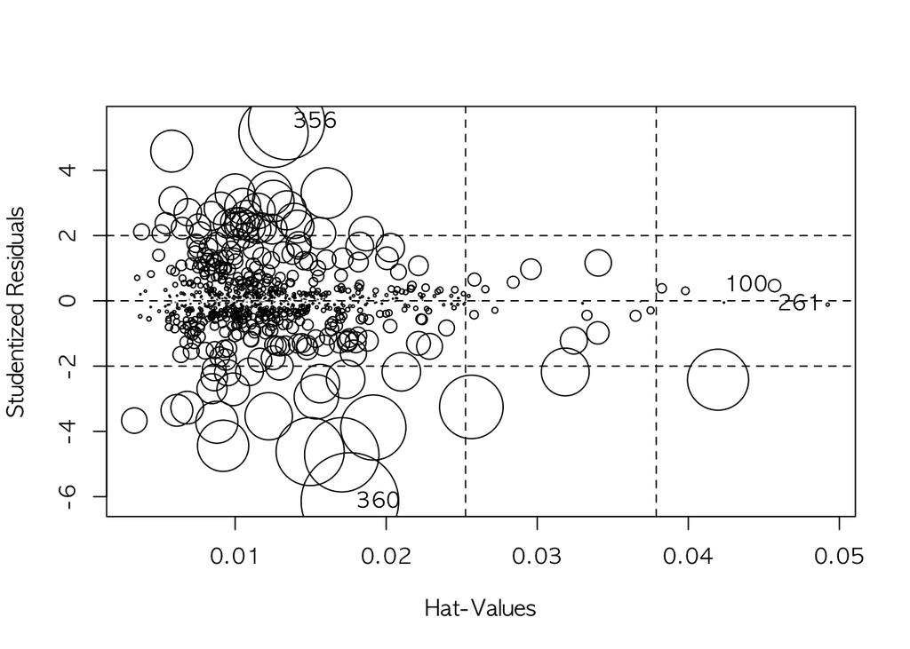

```
##        StudRes        Hat        CookD
## 100  0.4669734 0.04571253 1.045622e-03
## 261 -0.1156963 0.04922583 6.939092e-05
## 356  5.4906979 0.01340452 3.948882e-02
## 360 -6.1453631 0.01759868 6.461500e-02
```

```r
influencePlot(reg)
```

스튜던트화 잔차와 hat, cook의 D통계량을 확인해볼 수 있다.영향력있는 값은 100,261,356,360 이다.

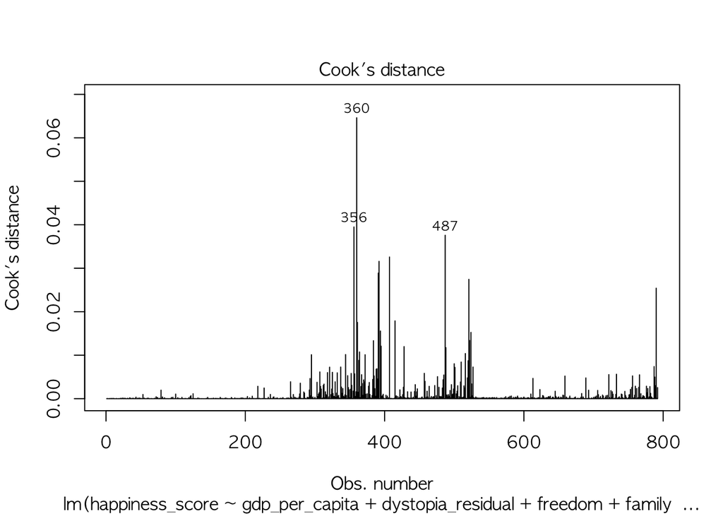

```r
plot(reg, which=4)
```

#### 변수변환

등분산성과 정규성을 만족시키기 위해 SAS를 통해 box-cox변환을 통해 종속변수, box-tidwell을 통해 설명변수의 변환을 진행해 보았다

SAS : https://zerobases.github.io/portfolio/visualization/regression_SAS.html

```r
yy=df$happiness_score**1.2

a2=df$family**1.6
a3=df$health**1.7
a4=df$freedom**1.8
a0=df$cpi_score**1.6

reg1<-lm(data=df, yy~gdp_per_capita+a2+a3+a4+generosity+government_trust+dystopia_residual+Year+dystopia_residual+a0)
summary(reg1)
```

```
##
## Call:
## lm(formula = yy ~ gdp_per_capita + a2 + a3 + a4 + generosity +
##     government_trust + dystopia_residual + Year + dystopia_residual +
##     a0, data = df)
##
## Residuals:
##      Min       1Q   Median       3Q      Max
## -1.75778 -0.11022 -0.00049  0.10543  1.46524
##
## Coefficients:
##                     Estimate Std. Error t value Pr(>|t|)
## (Intercept)       -8.748e+01  1.338e+01  -6.540 1.11e-10 ***
## gdp_per_capita     1.657e+00  4.859e-02  34.094  < 2e-16 ***
## a2                 1.102e+00  3.475e-02  31.705  < 2e-16 ***
## a3                 1.451e+00  6.399e-02  22.672  < 2e-16 ***
## a4                 2.305e+00  1.084e-01  21.255  < 2e-16 ***
## generosity         1.423e+00  9.226e-02  15.422  < 2e-16 ***
## government_trust   1.243e+00  1.343e-01   9.255  < 2e-16 ***
## dystopia_residual  1.617e+00  1.947e-02  83.024  < 2e-16 ***
## Year               4.331e-02  6.629e-03   6.533 1.16e-10 ***
## a0                 6.979e-05  5.759e-05   1.212    0.226
## ---
## Signif. codes:  0 '***' 0.001 '**' 0.01 '*' 0.05 '.' 0.1 ' ' 1
##
## Residual standard error: 0.2833 on 782 degrees of freedom
## Multiple R-squared:  0.9778, Adjusted R-squared:  0.9776
## F-statistic:  3830 on 9 and 782 DF,  p-value: < 2.2e-16
```

```r
shapiro.test(residuals(reg1)) #정규성
```

```
##
##  Shapiro-Wilk normality test
##
## data:  residuals(reg1)
## W = 0.89712, p-value < 2.2e-16
```

```r
ncvTest(reg1) #등분산
```

```
## Non-constant Variance Score Test
## Variance formula: ~ fitted.values
## Chisquare = 54.0038, Df = 1, p = 2.001e-13
```

이분산성이 소폭 해결 된 모습이 있지만, box-cox와 box-tidwell의 변환으로도 해결되지 않는다.

```r
reg2<-lm(data=dff, happiness_score~gdp_per_capita+family+health+freedom+generosity+government_trust+dystopia_residual+Year+cpi_score)
summary(reg2)
```

```
##
## Call:
## lm(formula = happiness_score ~ gdp_per_capita + family + health +
##     freedom + generosity + government_trust + dystopia_residual +
##     Year + cpi_score, data = dff)
##
## Residuals:
##      Min       1Q   Median       3Q      Max
## -0.60381 -0.05510 -0.00546  0.03931  0.54500
##
## Coefficients:
##                     Estimate Std. Error t value Pr(>|t|)
## (Intercept)       -4.918e+01  6.788e+00  -7.245 1.05e-12 ***
## gdp_per_capita     9.459e-01  2.594e-02  36.465  < 2e-16 ***
## family             1.027e+00  2.660e-02  38.618  < 2e-16 ***
## health             1.068e+00  3.795e-02  28.149  < 2e-16 ***
## freedom            1.092e+00  4.640e-02  23.540  < 2e-16 ***
## generosity         8.685e-01  4.710e-02  18.438  < 2e-16 ***
## government_trust   8.723e-01  6.538e-02  13.342  < 2e-16 ***
## dystopia_residual  9.787e-01  1.005e-02  97.365  < 2e-16 ***
## Year               2.440e-02  3.364e-03   7.254 9.86e-13 ***
## cpi_score          6.747e-04  4.741e-04   1.423    0.155
## ---
## Signif. codes:  0 '***' 0.001 '**' 0.01 '*' 0.05 '.' 0.1 ' ' 1
##
## Residual standard error: 0.146 on 775 degrees of freedom
## Multiple R-squared:  0.9833, Adjusted R-squared:  0.9831
## F-statistic:  5071 on 9 and 775 DF,  p-value: < 2.2e-16
```

이상점을 제거한 회귀 모델이다.

```r
shapiro.test(residuals(reg2)) #정규성
```

```
##
##  Shapiro-Wilk normality test
##
## data:  residuals(reg2)
## W = 0.89365, p-value < 2.2e-16
```

```r
ncvTest(reg2) #등분산
```

```
## Non-constant Variance Score Test
## Variance formula: ~ fitted.values
## Chisquare = 123.5224, Df = 1, p = < 2.22e-16
```

정규성과 이분산성이 해결되진 않았지만, Adjusted R이 상승한 것을 볼 수 있다.

<최종 회귀모델> -49.2+0.946*gdp_per_capita+1.03*family+1.07*health+1.09*freedom+0.869*generosity+0.872*government_trust+0.979*dystopia_residual+0.02*Year+0.0006*cpi_score